# EDA Playground

Charles Suresh

12/03/2021

### Testing explore_text_columns function:

Identified the following as text columns: sms

## Exploratory Data Analysis of “sms” column:

### Character Length:

- The average character length of text is: 80.07
- The median character length of text is: 61
- The longest text(s) has 910 characters:

“For me the love should start with attraction.i should feel that I need her every time around me.she should be the first thing which comes in my thoughts.I would start the day and end it with her.she should be there every time I dream.love will be then when my every breath has her name.my life should happen around her.my life will be named to her.I would cry for her.will give all my happiness and take all her sorrows.I will be ready to fight with anyone for her.I will be in love when I will be doing the craziest things for her.love will be when I don’t have to proove anyone that my girl is the most beautiful lady on the whole planet.I will always be singing praises for her.love will be when I start up making chicken curry and end up makiing sambar.life will be the most beautiful then.will get every morning and thank god for the day because she is with me.I would like to say a lot..will tell later..”

- The shortest text(s) has 2 characters:

“v2”

“Ok”

“Ok”

“:)”

“Ok”

“Ok”

#### Histogram of number of characters in “sms”:

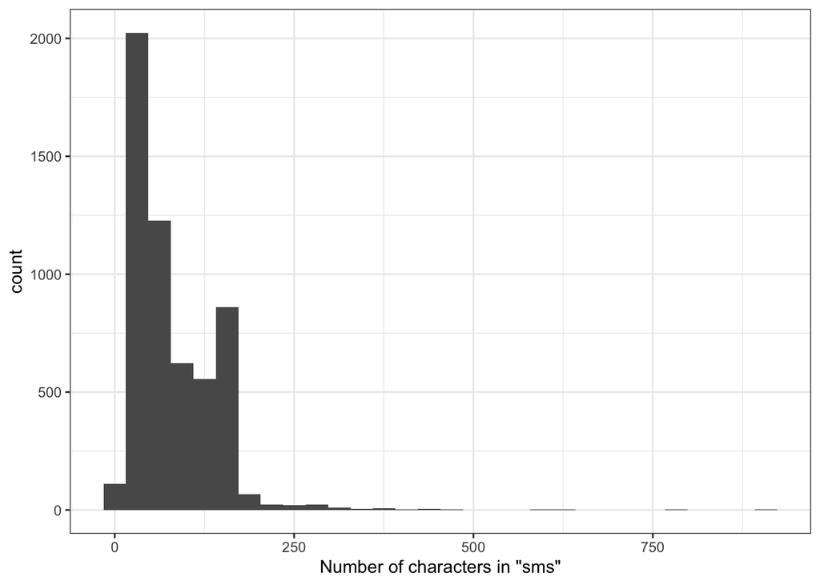

### Word Count:

- The average number of words in “sms” is: 16.17
- The median number of words in “sms” is: 12
- The text(s) in “sms” with most words (190 words):

“For me the love should start with attraction.i should feel that I need her every time around me.she should be the first thing which comes in my thoughts.I would start the day and end it with her.she should be there every time I dream.love will be then when my every breath has her name.my life should happen around her.my life will be named to her.I would cry for her.will give all my happiness and take all her sorrows.I will be ready to fight with anyone for her.I will be in love when I will be doing the craziest things for her.love will be when I don’t have to proove anyone that my girl is the most beautiful lady on the whole planet.I will always be singing praises for her.love will be when I start up making chicken curry and end up makiing sambar.life will be the most beautiful then.will get every morning and thank god for the day because she is with me.I would like to say a lot..will tell later..”

#### Histogram of number of words in “sms”:

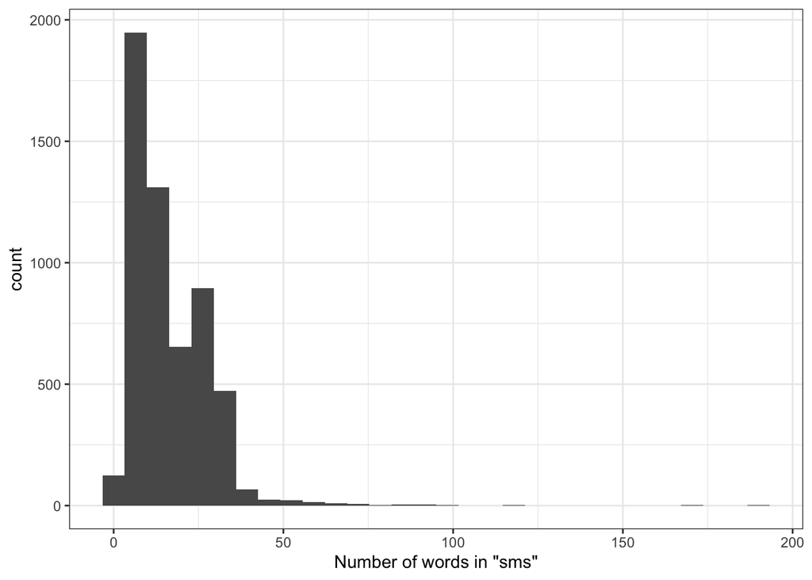

#### Word Cloud of text in “sms”:

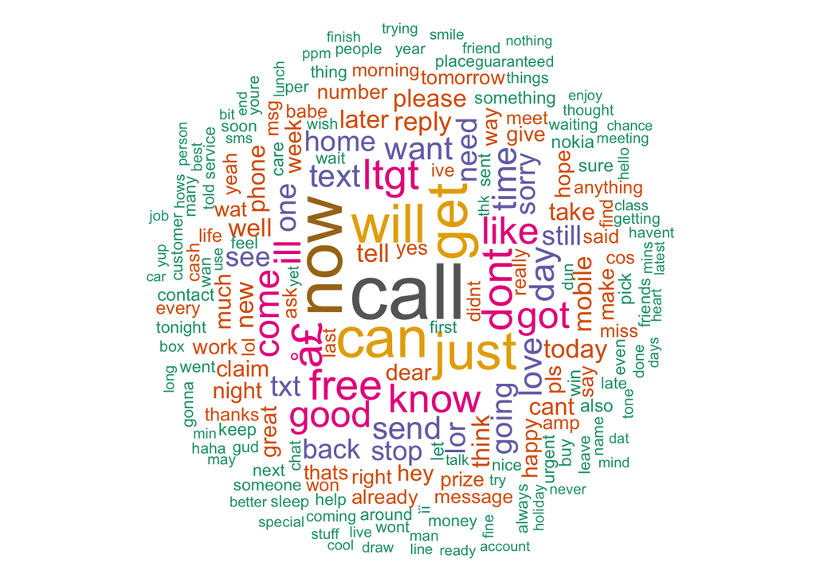

#### Bar chart of top 10 words in “sms”:

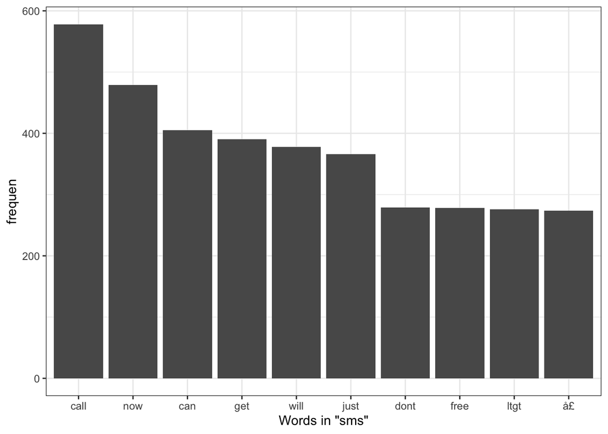

#### Word Cloud of Bigrams in “sms”:

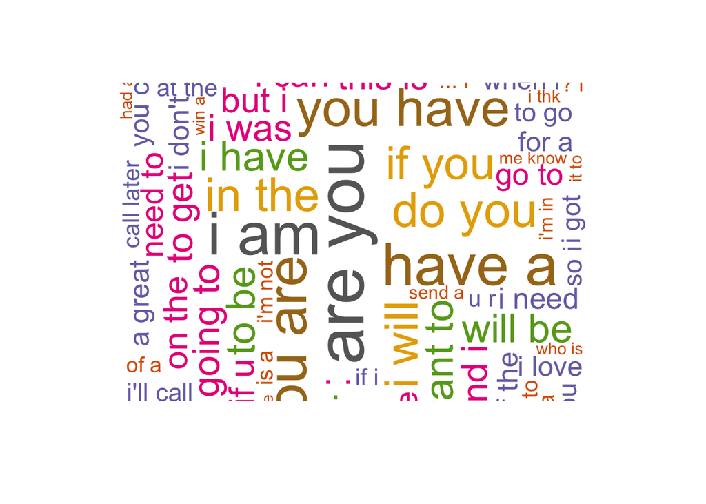

#### Bar chart of top 10 Bigrams in “sms”:

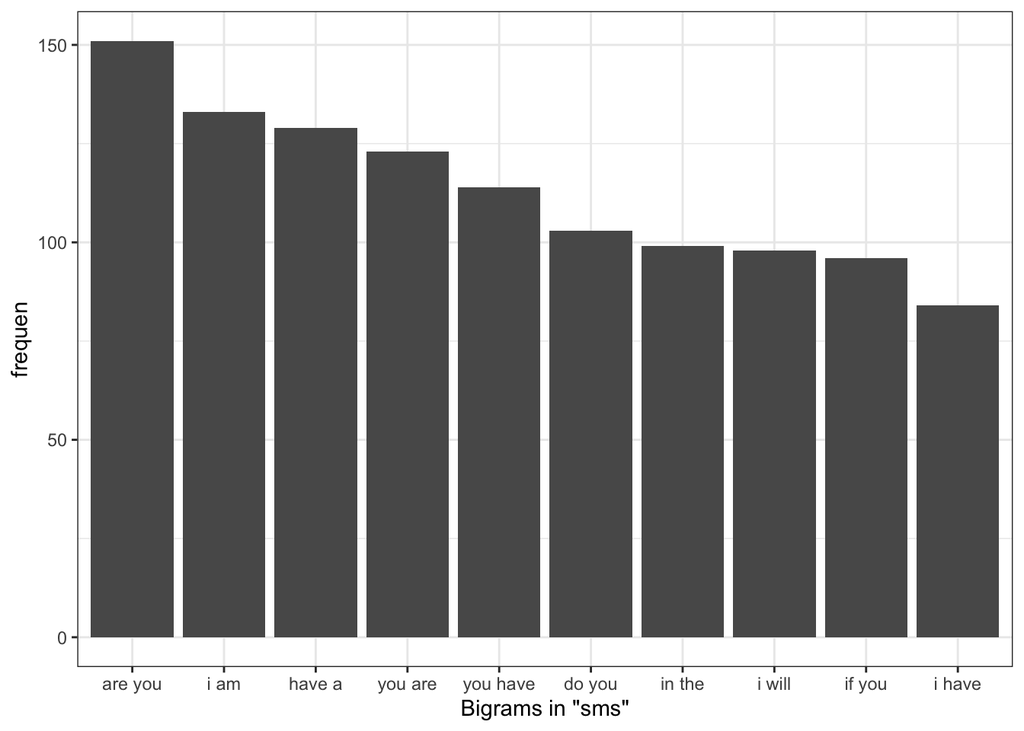

**End of Exploratory Data Analysis of Text Columns**

```r
library(palmerpenguins)
results <- explore_numeric_columns(penguins)
```

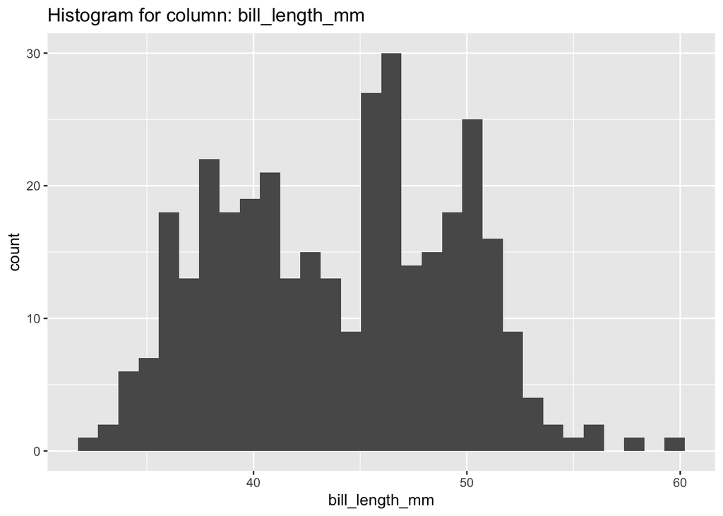

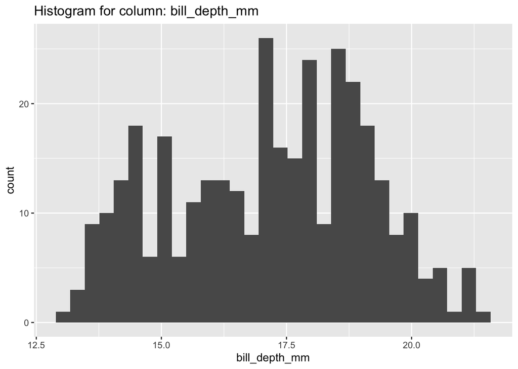

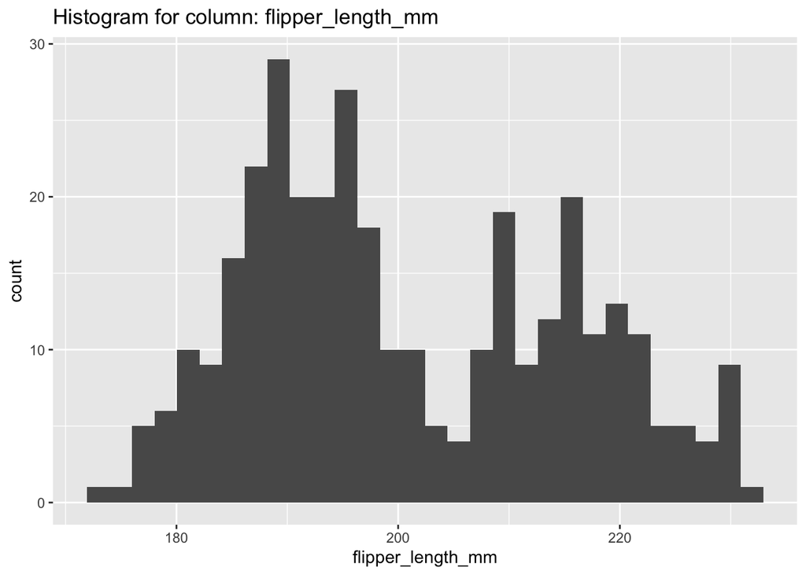

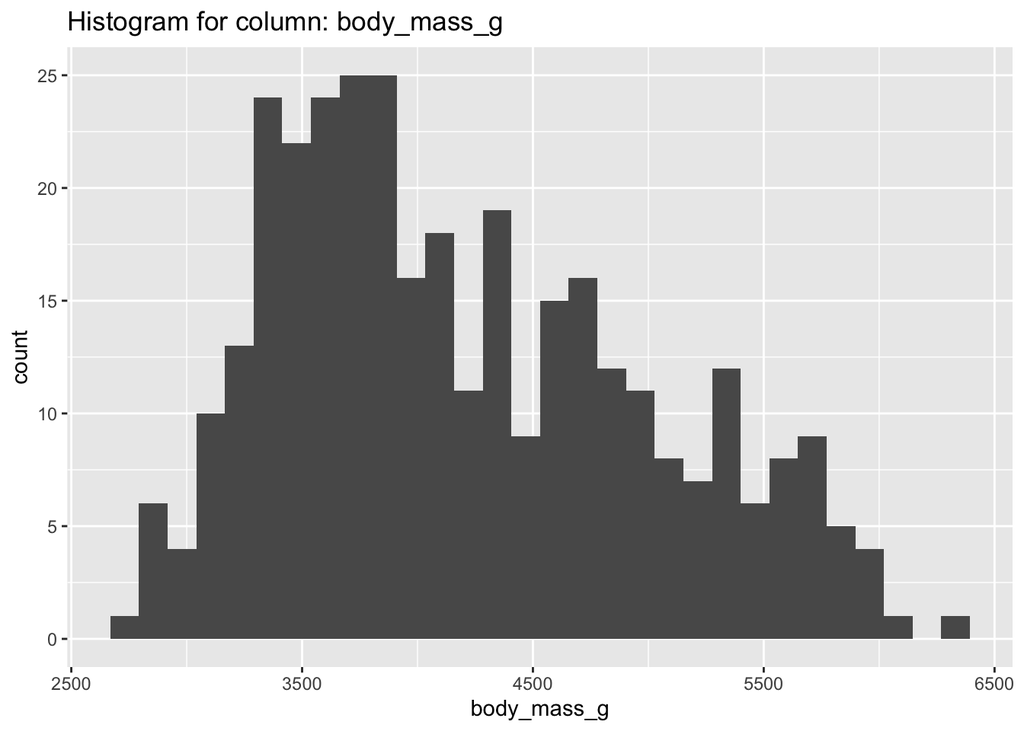

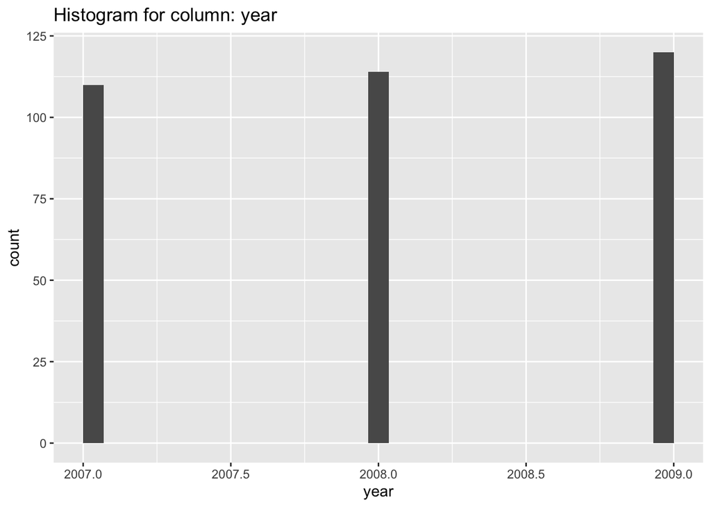

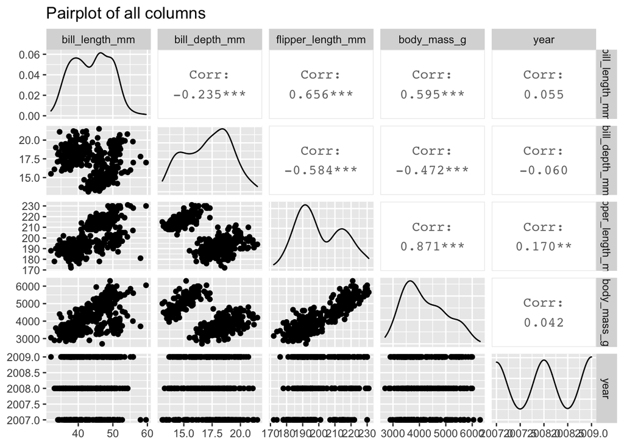

[figure not shown]

```r
library(dplyr)
library(MASS)
df <- data.frame(lapply(survey[, c('Sex','Clap')], as.character),
                 stringsAsFactors=FALSE) %>% tibble()

results <- explore_categorical_columns(df, c('Sex','Clap'))
results
```

```
## [[1]]
## # A tibble: 2 x 4
##   column_name unique_items             no_of_nulls percentage_missing
##   <chr>       <chr>                          <int>              <dbl>
## 1 Sex         Female, Male, NA                   1              0.422
## 2 Clap        Left, Neither, Right, NA           1              0.422
##
## [[2]]
## [[2]][[1]]
```

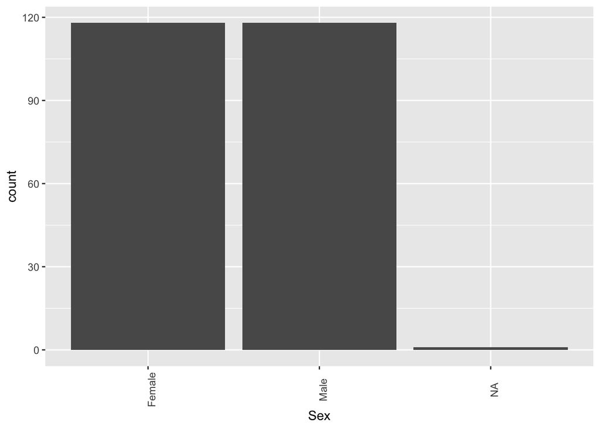

```
##
## [[2]][[2]]
```

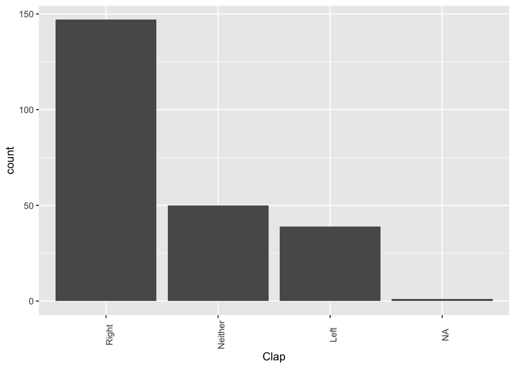